# Problem 2: Classification on 20newsgroup Data

Problem 1

```python
from sklearn.ensemble import RandomForestClassifier
from sklearn.model_selection import cross_val_score, train_test_split
from sklearn.metrics import confusion_matrix
import numpy as np
import pandas as pd
```

```python
data_frame = pd.read_csv('20newsgroup\data_set.csv')
```

```python
data_frame.head()
```

|  | group | aids | baseball | bible | bmw | cancer | car | card | case | children | ... | university | version | video | vitamin | war | water | win | windows | won | world |
| --- | --- | --- | --- | --- | --- | --- | --- | --- | --- | --- | --- | --- | --- | --- | --- | --- | --- | --- | --- | --- | --- |
| 0 | 1 | 0 | 0 | 0 | 0 | 0 | 0 | 0 | 0 | 0 | ... | 0 | 0 | 1 | 0 | 0 | 0 | 0 | 0 | 0 | 0 |
| 1 | 1 | 0 | 0 | 0 | 0 | 0 | 0 | 0 | 0 | 0 | ... | 0 | 0 | 0 | 0 | 0 | 0 | 0 | 0 | 0 | 0 |
| 2 | 1 | 0 | 0 | 0 | 0 | 0 | 0 | 0 | 0 | 0 | ... | 0 | 1 | 0 | 0 | 0 | 0 | 0 | 0 | 0 | 0 |
| 3 | 1 | 0 | 0 | 0 | 0 | 0 | 0 | 0 | 0 | 0 | ... | 1 | 0 | 0 | 0 | 0 | 0 | 0 | 0 | 0 | 0 |
| 4 | 1 | 0 | 0 | 0 | 0 | 0 | 0 | 0 | 0 | 0 | ... | 0 | 1 | 0 | 0 | 0 | 0 | 0 | 0 | 0 | 0 |

5 rows × 101 columns

```python
X_train, X_test, y_train, y_test = train_test_split(data_frame.iloc[:,1:], data_frame.iloc[:,0], test_size=0.2, random_state=20987228)
```

First we assume number of estimators is 100,and max features is sqrt

```python
rf = RandomForestClassifier(n_estimators=100, max_features="sqrt", random_state=42)
rf.fit(X_train, y_train)
```

```
RandomForestClassifier(max_features='sqrt', random_state=42)
```

```python
cv_error = 1 - np.mean(cross_val_score(rf, X_train, y_train, cv=5))
print(cv_error)
```

```
0.19995364475174182
```

```python
y_pred = rf.predict(X_test)
confusion_matrix = confusion_matrix(y_test, y_pred)
```

```python
print(confusion_matrix)
```

```
[[812  32  35  43]
 [ 49 563  26  78]
 [110  34 329  75]
 [ 38  30  44 951]]
```

Next, we do some gird search

```python
grid = {
    'n_estimators': [50,100,150,200],
    'max_features': ['sqrt', 'log2'],
    # 可添加更多参数
}
```

```python
rf = RandomForestClassifier(random_state=20987228)
grid_search = GridSearchCV(rf, grid, cv=5, scoring='accuracy', n_jobs=-1)
grid_search.fit(X_train, y_train)
```

```
GridSearchCV(cv=5, estimator=RandomForestClassifier(random_state=20987228),
             n_jobs=-1,
             param_grid={'max_features': ['sqrt', 'log2'],
                         'n_estimators': [50, 100, 150, 200]},
             scoring='accuracy')
```

```python
print(grid_search.best_params_)
```

```
{'max_features': 'log2', 'n_estimators': 200}
```

We find the performance would be better when take max_features as log2, and n_estimator as 200

```python
rf = RandomForestClassifier(n_estimators=200, max_features="log2", random_state=42)
rf.fit(X_train, y_train)
cv_error = 1 - np.mean(cross_val_score(rf, X_train, y_train, cv=5))
print(cv_error)
```

```
0.19664426508567134
```

```python
y_pred = rf.predict(X_test)
confusion_matrix = confusion_matrix(y_test, y_pred)
```

```python
print(confusion_matrix)
```

```
[[819  29  36  38]
 [ 51 568  22  75]
 [111  31 334  72]
 [ 34  25  42 962]]
```

In fact, it didn't improve so much

Problem 2

```python
from sklearn.ensemble import GradientBoostingClassifier
```

```python
grid = {
    'n_estimators': [ 100, 200,300],
    'learning_rate': [0.01, 0.1] ,
    'max_depth':[5,10]

}

gbc = GradientBoostingClassifier(random_state=20987228)
grid_search = GridSearchCV(gbc, grid, cv=5, scoring='accuracy', n_jobs=-1)
grid_search.fit(X_train, y_train)
print(grid_search.best_params_)
```

```
{'learning_rate': 0.1, 'max_depth': 5, 'n_estimators': 200}
```

```python
gbc = GradientBoostingClassifier(random_state=20987228,learning_rate = 0.1,n_estimators = 200,max_depth = 5)
gbc.fit(X_train, y_train)
cv_error = 1 - np.mean(cross_val_score(gbc, X_train, y_train, cv=5))
print(cv_error)
```

```
0.18302180533106094
```

```python
y_pred = gbc.predict(X_test)
confusion_matrix = confusion_matrix(y_test, y_pred)
```

```python
print(confusion_matrix)
```

```
[[822  11  47  42]
 [ 53 547  33  83]
 [108  15 355  70]
 [ 39  30  46 948]]
```

Comparing the results from random forest and boosting trees, we observe that the latter model exhibits a relatively smaller classification cv_error.

Problem 4

```python
from sklearn.discriminant_analysis import LinearDiscriminantAnalysis
lda = LinearDiscriminantAnalysis()
lda.fit(X_train, y_train)
cv_error = 1 - np.mean(cross_val_score(lda, X_train, y_train, cv=5))
print(cv_error)
```

```
0.20488024499267055
```

Problem 5

```python
from sklearn.discriminant_analysis import QuadraticDiscriminantAnalysis
qda = QuadraticDiscriminantAnalysis()
qda.fit(X_train, y_train)
cv_error = 1 - np.mean(cross_val_score(qda, X_train, y_train, cv=5))
print(cv_error)
```

```
0.2928521984383762
```

Problem 6

```python
from sklearn.svm import SVC
svm = SVC(kernel='linear', random_state=20987228)
svm.fit(X_train, y_train)
cv_error = 1 - np.mean(cross_val_score(svm, X_train, y_train, cv=5))
print(cv_error)
```

```
0.19402793340602076
```

Under comparesion these 3 methods, we can find that, SVM model have a better performance with 0.194 cv_error, and QDA have the worst performance,it's cv error is nearly 30. these methods is not good for do this classification task.

# Problem 3 Spectral Clustering (PCA + K-means)on 20newsgroup Data

```python
import numpy as np
from sklearn.cluster import KMeans
from matplotlib import pyplot as plt
import random
```

```python
class K_Means:
    def __init__(self, k=2):
        self.k_ = k
    def calculate_difference(self,dict1, dict2):
        diff_dict = {}

        # 遍历第一个字典的键值对
        for key, value in dict1.items():
            if key in dict2:
                # 检查第二个字典是否包含相同的键
                value_diff = value - dict2[key]
                diff_dict[key] = np.linalg.norm(value_diff, ord=2)  # 计算二范数并存储在差异字典中

        return diff_dict
    def fit(self, train_data):
        self.centers_ = {}
        # initialy random select 2 points from train data as centers
        random_center = random.sample(range(len(train_data)), self.k_)
        for i in range(self.k_):
            self.centers_[i] = train_data[random_center[i]]
        while True:#change the center for 300 times
            self.clf_ = {}
            self.label_ = []
            for j in range(self.k_):
                self.clf_[j] = []
            for data_point in train_data:
                distance = []
                for center in self.centers_:
                    distance.append(np.linalg.norm(data_point - self.centers_[center]))#Obtain Euclidean distance (second norm)
                classification = distance.index(min(distance))#Find the distance to the nearest central point
                self.label_.append(classification)
                self.clf_[classification].append(data_point)

            prev_centers = dict(self.centers_)
#             print(prev_centers)
            for c in self.clf_:
                self.centers_[c] = np.average(self.clf_[c], axis=0)
#             print(self.centers_)
            difference_values = self.calculate_difference(prev_centers,self.centers_)
#             print(difference_values)
#             print(list(difference_values))
            difference_sum = np.sum(list(difference_values.values()))
            #print(difference_sum)
            if (difference_sum<= 0.0001):
                break
    def predict(self,predict_data):
        label_list = []
        for data_point in predict_data:


            distance = []
            for center in self.centers_:
                distance.append(np.linalg.norm(data_point - self.centers_[center]))#Obtain Euclidean distance (second norm)

                classification = distance.index(min(distance))
            label_list.append(classification)
        return(label_list)

        #return classification
```

test

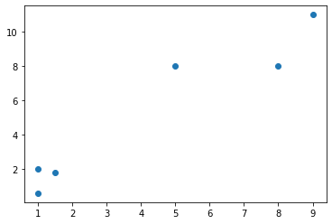

```python
x = np.array([ [1,2],[1.5,1.8],[5,8],[8,8],[1,0.6],[9,11] ])
plt.scatter(x[:,0], x[:,1])
plt.show()
```

```
{0: array([1.16666667, 1.46666667]), 1: array([7.33333333, 9.        ])}
[0, 1, 1]
```

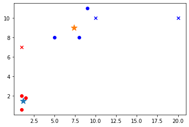

```python
x = np.array([[1, 2], [1.5, 1.8], [5, 8], [8, 8], [1, 0.6], [9, 11]])
k_means = K_Means(k=2)
k_means.fit(x)
for center in k_means.centers_:
        pyplot.scatter(k_means.centers_[center][0], k_means.centers_[center][1], marker='*', s=150)
print(k_means.centers_)
for cat in k_means.clf_:
        for point in k_means.clf_[cat]:
            pyplot.scatter(point[0], point[1], c=('r' if cat == 0 else 'b'))
predict = [[1, 7], [20, 10],[10,10]]
cat = k_means.predict(predict)
print(cat)
for i in range(len(cat)):
    pyplot.scatter(predict[i][0], predict[i][1], c=('r' if cat[i] == 0 else 'b'), marker='x')
```

Problem 2

```python
from sklearn.decomposition import PCA
```

```python
data_frame = pd.read_csv('20newsgroup\data_set.csv')
```

```python
occurrence_matrix = data_frame.iloc[:,1:]
```

```python
occurrence_matrix
```

|  | aids | baseball | bible | bmw | cancer | car | card | case | children | christian | ... | university | version | video | vitamin | war | water | win | windows | won | world |
| --- | --- | --- | --- | --- | --- | --- | --- | --- | --- | --- | --- | --- | --- | --- | --- | --- | --- | --- | --- | --- | --- |
| 0 | 0 | 0 | 0 | 0 | 0 | 0 | 0 | 0 | 0 | 0 | ... | 0 | 0 | 1 | 0 | 0 | 0 | 0 | 0 | 0 | 0 |
| 1 | 0 | 0 | 0 | 0 | 0 | 0 | 0 | 0 | 0 | 0 | ... | 0 | 0 | 0 | 0 | 0 | 0 | 0 | 0 | 0 | 0 |
| 2 | 0 | 0 | 0 | 0 | 0 | 0 | 0 | 0 | 0 | 0 | ... | 0 | 1 | 0 | 0 | 0 | 0 | 0 | 0 | 0 | 0 |
| 3 | 0 | 0 | 0 | 0 | 0 | 0 | 0 | 0 | 0 | 0 | ... | 1 | 0 | 0 | 0 | 0 | 0 | 0 | 0 | 0 | 0 |
| 4 | 0 | 0 | 0 | 0 | 0 | 0 | 0 | 0 | 0 | 0 | ... | 0 | 1 | 0 | 0 | 0 | 0 | 0 | 0 | 0 | 0 |
| ... | ... | ... | ... | ... | ... | ... | ... | ... | ... | ... | ... | ... | ... | ... | ... | ... | ... | ... | ... | ... | ... |
| 16237 | 0 | 0 | 0 | 0 | 0 | 0 | 0 | 0 | 0 | 0 | ... | 0 | 0 | 0 | 0 | 0 | 0 | 0 | 0 | 0 | 0 |
| 16238 | 0 | 0 | 0 | 0 | 0 | 0 | 0 | 0 | 0 | 0 | ... | 0 | 0 | 0 | 0 | 0 | 0 | 0 | 0 | 0 | 0 |
| 16239 | 0 | 0 | 0 | 0 | 0 | 0 | 0 | 0 | 0 | 1 | ... | 0 | 0 | 0 | 0 | 0 | 0 | 1 | 0 | 0 | 0 |
| 16240 | 0 | 0 | 0 | 0 | 0 | 0 | 0 | 0 | 0 | 0 | ... | 0 | 0 | 0 | 0 | 0 | 0 | 0 | 0 | 0 | 1 |
| 16241 | 0 | 0 | 0 | 0 | 0 | 0 | 0 | 0 | 0 | 1 | ... | 0 | 0 | 0 | 0 | 0 | 0 | 0 | 0 | 0 | 0 |

16242 rows × 100 columns

```python
pca = PCA(n_components=4)
singular_vectors = pca.fit_transform(occurrence_matrix)
```

```python
singular_vectors[:10]
```

```
array([[ 0.09725084,  0.72355366,  0.37168084, -0.06025652],
       [-0.29544357, -0.16735527,  0.15453398,  0.15594552],
       [-0.24786788,  0.28215541,  0.04644827,  0.07595447],
       [-0.19298501,  0.41508968,  0.82906179, -0.48541374],
       [-0.12360964,  0.38961209,  0.12312901,  0.15977925],
       [-0.20521948,  0.01826588, -0.03171292,  0.09593449],
       [ 0.02399533,  0.68906691,  0.43578386, -0.29719677],
       [-0.06342986,  0.29999905,  0.33899378, -0.31892955],
       [ 0.24340537,  0.63195361,  1.04644662, -0.34879521],
       [-0.05853238,  0.57331061,  0.17062308, -0.85434398]])
```

```python
k_means = K_Means(k=4)
start_time = time.time()
k_means.fit(singular_vectors)
end_time = time.time()
print("Cost time is {}".format(end_time - start_time))
```

```
Cost time is 6.671731233596802
```

```python
cluster_labels = k_means.label_
true_labels = data_frame.iloc[:,1]
```

```python
import numpy as np
from scipy.optimize import linear_sum_assignment
from sklearn.metrics import accuracy_score


# Gets unique values for real and cluster categories
unique_true_labels = np.unique(true_labels)
unique_cluster_labels = np.unique(cluster_labels)

# Create a cost matrix for category matching
cost_matrix = np.zeros((len(unique_true_labels), len(unique_cluster_labels)))

# Filling cost matrix
for i, true_label in enumerate(unique_true_labels):
    for j, cluster_label in enumerate(unique_cluster_labels):
        # Calculate the number of mismatches as a cost
        mismatch_count = np.sum((true_labels == true_label) & (cluster_labels == cluster_label))
        cost_matrix[i, j] = -mismatch_count

# Find the best match through the least cost match
row_ind, col_ind = linear_sum_assignment(cost_matrix)

# Category re-labeling based on matching results
mapped_labels = np.zeros_like(cluster_labels)
for true_label, cluster_label in zip(unique_true_labels[row_ind], unique_cluster_labels[col_ind]):
    mapped_labels[cluster_labels == cluster_label] = true_label

# Correct rate of calculation
accuracy = accuracy_score(true_labels, mapped_labels)

# Output result
print("Mis-clustering error rate:", 1-accuracy)
```

```
Mis-clustering error rate: 0.1281861839674917
```

```python
len(mapped_labels)
```

```
16242
```

Problem 3

```python
pca = PCA(n_components=5)
singular_vectors = pca.fit_transform(occurrence_matrix)
```

```python
k_means = K_Means(k=4)
start_time = time.time()
k_means.fit(singular_vectors)
end_time = time.time()
print("Cost time is {}".format(end_time - start_time))
```

```
Cost time is 10.195596694946289
```

```python
cluster_labels = k_means.label_
true_labels = data_frame.iloc[:,1]
# Gets unique values for real and cluster categories
unique_true_labels = np.unique(true_labels)
unique_cluster_labels = np.unique(cluster_labels)

# Create a cost matrix for category matching
cost_matrix = np.zeros((len(unique_true_labels), len(unique_cluster_labels)))

# Filling cost matrix
for i, true_label in enumerate(unique_true_labels):
    for j, cluster_label in enumerate(unique_cluster_labels):
        # Calculate the number of mismatches as a cost
        mismatch_count = np.sum((true_labels == true_label) & (cluster_labels == cluster_label))
        cost_matrix[i, j] = -mismatch_count

# Find the best match through the least cost match
row_ind, col_ind = linear_sum_assignment(cost_matrix)

# Category re-labeling based on matching results
mapped_labels = np.zeros_like(cluster_labels)
for true_label, cluster_label in zip(unique_true_labels[row_ind], unique_cluster_labels[col_ind]):
    mapped_labels[cluster_labels == cluster_label] = true_label

# Correct rate of calculation
accuracy = accuracy_score(true_labels, mapped_labels)

# Output result
print("Mis-clustering error rate:", 1-accuracy)
```

```
Mis-clustering error rate: 0.1267085334318434
```

Problem 5

Here shows the 2-dimensional.

```python
pca_2D = PCA(n_components = 2)
singular_vectors = pca_2D.fit_transform(occurrence_matrix)
```

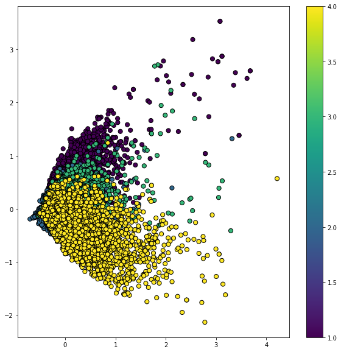

```python
plt.figure(figsize=(10,10))
plt.scatter(singular_vectors[:,0],singular_vectors[:,1],c = data_frame.iloc[:,0],cmap = 'viridis',edgecolor = 'k',s = 50)
plt.colorbar()
plt.show()
```

Here shows the 3-dimensional.

```python
pca_3D = PCA(n_components =3)
singular_vectors = pca_3D.fit_transform(occurrence_matrix)
from mpl_toolkits.mplot3d import Axes3D
```

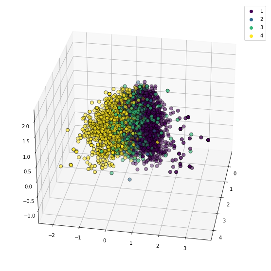

```python
fig = plt.figure(figsize=(10,10))
ax = fig.add_subplot(111,projection = '3d')
sc = ax.scatter(singular_vectors[:,0],singular_vectors[:,1],singular_vectors[:,2],c = data_frame.iloc[:,0],cmap = 'viridis',edgecolor = 'k',s = 50)
legend1 = ax.legend(*sc.legend_elements())
ax.view_init(elev=30, azim=10)
```

# Problem 4 Classification on MNIST Data

```python
import numpy as np
import pandas as pd
from sklearn.svm import SVC
from sklearn.model_selection import GridSearchCV
from sklearn.metrics import confusion_matrix, accuracy_score
import time
```

Problem 1

```python
train_data_frame = pd.read_csv('MNIST/train_resized.csv')
(train_data_frame) = train_data_frame.loc[train_data_frame['label'].isin([3,6])]
train_data_frame['label'] = np.where(train_data_frame['label'] == 3, 1, 0)
num_of_train = len(train_data_frame['label'])
x_train = train_data_frame.iloc[:,1:].values


y_train = train_data_frame.iloc[:,0].values
```

```python
y_train
```

```
array([1, 0, 0, ..., 0, 0, 0])
```

```python
test_data_frame = pd.read_csv('MNIST/test_resized.csv')
(test_data_frame) = test_data_frame.loc[test_data_frame['label'].isin([3,6])]
test_data_frame['label'] = np.where(test_data_frame['label'] == 3, 1, 0)
num_of_test = len(test_data_frame['label'])
x_test = test_data_frame.iloc[:,1:].values

y_test = test_data_frame.iloc[:,0].values
```

```python
y_test
```

```
array([1, 0, 1, ..., 1, 1, 0])
```

```python
np.shape(x_train )
```

```
(6026, 144)
```

```python
# 定义参数网格
param_grid = {'C': [1, 10, 100, 1000]}#When using grid search, GridSearchCV tries each parameter combination specified in param_grid and evaluates the model's performance in cross-validation. The optimal hyperparameter configuration can be found by selecting the parameter combination with the best performance
svm_model = SVC(kernel='linear')#use linear kernel
grid_search = GridSearchCV(svm_model, param_grid, cv=5)#by 5 fold cross validation

grid_search.fit(x_train, y_train)
end_time = time.time()
```

```python
best_params = grid_search.best_params_
best_cost = best_params['C']
print(best_params,best_cost)
```

```
{'C': 1} 1
```

```python
good_model = SVC(kernel='linear', C=1)
start_time = time.time()
good_model.fit(x_train, y_train)
end_time = time.time()
```

```python
y_pred = good_model.predict(x_test)
```

```python
accurate = accuracy_score(y_test, y_pred)#test accurate
print("Misclassification error is {}".format(1-accurate))
```

```
Misclassification error is 0.008123476848091005
```

```python
confusion_mat = confusion_matrix(y_test, y_pred)
print("Confusion matrix:")
print(confusion_mat)
```

```
Confusion matrix:
[[1190   10]
 [  10 1252]]
```

```python
print("Time cost for modeling is {}".format(end_time - start_time))
```

```
Time cost for modeling is 0.17507481575012207
```

Problem 2

```python
param_grid = {'C': [0.01,0.1, 1, 10], 'gamma': [0.00001,0.0001,0.001,0.01,0.1, 1, 10]}
svm_model = SVC(kernel='rbf')
grid_search = GridSearchCV(svm_model, param_grid, cv=5)
```

```python
grid_search.fit(x_train, y_train)
```

```
GridSearchCV(cv=5, estimator=SVC(),
             param_grid={'C': [0.01, 0.1, 1, 10],
                         'gamma': [1e-05, 0.0001, 0.001, 0.01, 0.1, 1, 10]})
```

```python
best_params = grid_search.best_params_
best_cost = best_params['C']
best_gamma = best_params['gamma']
print(best_params,best_cost)
```

```
{'C': 1, 'gamma': 1e-05} 1
```

```python
good_svm_model = SVC(kernel='rbf', C=1, gamma=.00001)
start_time = time.time()
good_svm_model.fit(x_train, y_train)
end_time = time.time()
```

```python
y_pred = good_svm_model.predict(x_test)
```

```python
accurate = accuracy_score(y_test, y_pred)#test accurate
print("Misclassification error is {}".format(1-accurate))
```

```
Misclassification error is 0.0012185215272136896
```

```python
confusion_mat = confusion_matrix(y_test, y_pred)
print("Confusion matrix:")
print(confusion_mat)
```

```
Confusion matrix:
[[1197    3]
 [   0 1262]]
```

```python
print("Time cost for modeling is {}".format(end_time - start_time))
```

```
Time cost for modeling is 0.9599082469940186
```

Problem 3

In solving the problem of binary image classification, the performance of these two methods is similar, but the latter consumes significantly more time compared to the former.

Problem 4

```python
train_data_frame = pd.read_csv('MNIST/train_resized.csv')
train_data_frame_4 = train_data_frame.loc[train_data_frame['label'].isin([1,2,5,8])]
x_train = train_data_frame_4.iloc[:,1:].values
y_train = train_data_frame_4.iloc[:,0].values
```

```python
test_data_frame = pd.read_csv('MNIST/test_resized.csv')
test_data_frame_4 = test_data_frame.loc[test_data_frame['label'].isin([1,2,5,8])]
x_test = test_data_frame_4.iloc[:,1:].values
y_test = test_data_frame_4.iloc[:,0].values
```

```python
len(x_train)
```

```
11913
```

```python
param_grid = {'C': [0.000001,0.00001,0.0001]}
svm_model = SVC(kernel='linear')
```

```python
grid_search = GridSearchCV(svm_model, param_grid, cv=5)
```

```python
start_time = time.time()
grid_search.fit(x_train, y_train)
end_time = time.time()
```

```python
best_params = grid_search.best_params_
best_cost = best_params['C']
print(best_params,best_cost)
print(end_time-start_time)
```

```
{'C': 1e-05} 1e-05
18.024085521697998
```

```python
good_model = SVC(kernel='linear', C=0.00001)
good_model.fit(x_train, y_train)
```

```
SVC(C=1e-05, kernel='linear')
```

```python
y_pred = good_model.predict(x_test)
accurate = accuracy_score(y_test, y_pred)#test accurate
print("Misclassification error is {}".format(1-accurate))
```

```
Misclassification error is 0.046608406158968
```

```python
confusion_mat = confusion_matrix(y_test, y_pred)
print("Confusion matrix:")
print(confusion_mat)
```

```
Confusion matrix:
[[1343   11    1    8]
 [   9 1129   25   22]
 [  15   16 1063   32]
 [  22   18   45 1047]]
```

Problem 5

```python
x_train = train_data_frame.iloc[:,1:].values
y_train = train_data_frame.iloc[:,0].values
```

```python
x_test = test_data_frame.iloc[:,1:].values
y_test = test_data_frame.iloc[:,0].values
```

```python
param_grid = {'C': [0.000001,0.00001,0.0001]}
svm_model = SVC(kernel='linear')
```

```python
grid_search = GridSearchCV(svm_model, param_grid, cv=5)
```

```python
start_time = time.time()
grid_search.fit(x_train, y_train)
end_time = time.time()
```

```python
best_params = grid_search.best_params_
best_cost = best_params['C']
print(best_params,best_cost)
print(end_time-start_time)
```

```
{'C': 0.0001} 0.0001
140.25383281707764
```

```python
good_model = SVC(kernel='linear', C=0.00001)
good_model.fit(x_train, y_train)
```

```
SVC(C=1e-05, kernel='linear')
```

```python
y_pred = good_model.predict(x_test)
accurate = accuracy_score(y_test, y_pred)#test accurate
print("Misclassification error is {}".format(1-accurate))
```

```
Misclassification error is 0.06225000000000003
```

```python
confusion_mat = confusion_matrix(y_test, y_pred)
print("Confusion matrix:")
print(confusion_mat)
```

```
Confusion matrix:
[[1117    0    1    4    0    8    5    0    5    0]
 [   0 1342    8    5    0    0    1    1    6    0]
 [   7    3 1109    4   18    6   12    8   14    4]
 [   4    8   27 1145    0   39    2   11   16   10]
 [   3    3   11    0 1120    1    7    2    1   27]
 [   9   12    4   46    5 1010   13    1   22    4]
 [   9    1    8    0   12   11 1155    0    4    0]
 [   1    3   17    5   10    5    0 1182    1   40]
 [  10   16   13   26    6   28    4    4 1016    9]
 [   4    7    7    9   31    3    0   28    7 1057]]
```

# Problem 5 Deep learning on MNIST Data

```python
import sys
import numpy as np
import pandas as pd
import matplotlib.pyplot as plt
import sklearn
import time
import tensorflow as tf
from tensorflow import keras

from sklearn.model_selection import train_test_split
```

```python
def plot_image(image):
    # Remove redundant extra dimension
    if image.shape[-1] == -1:
        image = image.squeeze(axis=1)

    plt.imshow(image, cmap="gray", interpolation="nearest")
    plt.axis("off")
```

```python
def plot_color_image(image):
    # Remove redundant extra dimension
    if image.shape[-1] == 1:
        image = image.squeeze(axis=1)

    plt.imshow(image, interpolation="nearest")
    plt.axis("off")
```

```python
train_data_frame = pd.read_csv('MNIST/train_resized.csv')
x_train = train_data_frame.iloc[:,1:].values
x_train = x_train.reshape(30000, 12, 12)
y_train = train_data_frame.iloc[:,0].values
print(np.shape(x_train[0]))
```

```
(12, 12)
```

```python
test_data_frame = pd.read_csv('MNIST/test_resized.csv')
x_test = test_data_frame.iloc[:,1:].values
x_test = x_test.reshape(12000, 12, 12)
y_test = test_data_frame.iloc[:,0].values
```

```
8
Shape of X_train: (30000, 12, 12)
```

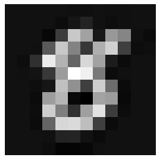

```python
plot_image(x_train[667])
print(y_train[667])
print(f"Shape of X_train: {x_train.shape}")
```

```
1
Shape of X_train: (12000, 12, 12)
```

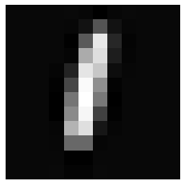

```python
plot_image(x_test[667])
print(y_test[667])
print(f"Shape of X_train: {x_test.shape}")
```

```python
x_train, x_valid, y_train, y_valid = train_test_split(x_train, y_train, train_size=0.9)
```

```python
x_train = np.expand_dims(x_train, -1)
x_test = np.expand_dims(x_test, -1)
print(f"Shape of X_train: {x_train.shape}")
print(f"Shape of X_train: {x_test.shape}")
```

```
Shape of X_train: (27000, 12, 12, 1)
Shape of X_train: (12000, 12, 12, 1)
```

```python
model = keras.Sequential([

    # Specify the input shape
    keras.Input(shape=(12, 12, 1)),

    # Conv and pool block 1
    keras.layers.Conv2D(16, kernel_size=(3, 3), activation="relu"),
    keras.layers.MaxPooling2D(pool_size=(2, 2)),

    # Conv and pool block 2
    keras.layers.Conv2D(32, kernel_size=(3, 3), activation="relu"),
    keras.layers.MaxPooling2D(pool_size=(2, 2)),

    # Flatten and classify using dense output layer
    keras.layers.Flatten(),
    keras.layers.Dropout(0.5),
    keras.layers.Dense(10, activation="softmax"),
])
```

```python
model.summary()
```

```
Model: "sequential"
_________________________________________________________________
 Layer (type)                Output Shape              Param #
=================================================================
 conv2d (Conv2D)             (None, 10, 10, 16)        160

 max_pooling2d (MaxPooling2D  (None, 5, 5, 16)         0
 )

 conv2d_1 (Conv2D)           (None, 3, 3, 32)          4640

 max_pooling2d_1 (MaxPooling  (None, 1, 1, 32)         0
 2D)

 flatten (Flatten)           (None, 32)                0

 dropout (Dropout)           (None, 32)                0

 dense (Dense)               (None, 10)                330

=================================================================
Total params: 5,130
Trainable params: 5,130
Non-trainable params: 0
_________________________________________________________________
```

```python
model.compile(loss='sparse_categorical_crossentropy',
              optimizer="adam",
              metrics=['accuracy'])
```

```python
"""Running this cell could take several minutes"""

# Train the model for 10 epochs with batch size 128
batch_size = 128
epochs = 30
history = model.fit(x_train, y_train, batch_size=batch_size,
                    epochs=epochs, validation_data=(x_valid, y_valid))
```

[output not shown]

```python
def plot_examples(data, n_rows=4, n_cols=10):
    """Plot a grid of images which are encoded as numpy arrays."""

    # Remove redundant extra dimension
    if data.shape[-1] == 1:
        data = data.squeeze(axis=-1)


    # Size figure depending on the size of the grid
    plt.figure(figsize=(n_cols * 1.2, n_rows * 1.2))

    for row in range(n_rows):
        for col in range(n_cols):

            # Get next index of image
            index = n_cols * row + col

            # Plot the image at appropriate place in grid
            plt.subplot(n_rows, n_cols, index + 1)
            plt.imshow(data[index], cmap="binary")
            plt.axis('off')

    plt.show()
```

```python
# Sample several test examples
X_test_sample = x_test[3:6]

# Get probability of each class from model
y_proba = model.predict(X_test_sample)
y_pred = np.argmax(y_proba, axis=-1)
print(y_pred)

plot_examples(x_test[3:6], n_rows=1, n_cols=3)
```

[output not shown]

```
[7 2 0]
```